Micro Projeto em R de Machine Learning, nele usaremos decisions trees e depois floresta aleatória para classificar escolas como Públicas ou Privadas baseadas em suas características. Será utilizado o dataframe College que vem com a livraria ISLR.

Carregando as livrarias:

```r
install.packages("ggplot2","ISLR","dplyr","caToolds","rpart","rpart.plot","randomForest")
library(ggplot2)
library(ISLR)
library(dplyr)
library(caTools)
library(rpart)
```

Montando e exibindo o dataframe:

```r
df <- College
head(College)
```

|  | Private | Apps | Accept | Enroll | Top10perc | Top25perc | F.Undergrad | P.Undergrad | Outstate | Room.Board | Books | Personal | PhD | Terminal | S.F.Ratio | perc.alumni | Expend | Grad.Rate |
| --- | --- | --- | --- | --- | --- | --- | --- | --- | --- | --- | --- | --- | --- | --- | --- | --- | --- | --- |
| Abilene Christian University | Yes | 1660 | 1232 | 721 | 23 | 52 | 2885 | 537 | 7440 | 3300 | 450 | 2200 | 70 | 78 | 18.1 | 12 | 7041 | 60 |
| Adelphi University | Yes | 2186 | 1924 | 512 | 16 | 29 | 2683 | 1227 | 12280 | 6450 | 750 | 1500 | 29 | 30 | 12.2 | 16 | 10527 | 56 |
| Adrian College | Yes | 1428 | 1097 | 336 | 22 | 50 | 1036 | 99 | 11250 | 3750 | 400 | 1165 | 53 | 66 | 12.9 | 30 | 8735 | 54 |
| Agnes Scott College | Yes | 417 | 349 | 137 | 60 | 89 | 510 | 63 | 12960 | 5450 | 450 | 875 | 92 | 97 | 7.7 | 37 | 19016 | 59 |
| Alaska Pacific University | Yes | 193 | 146 | 55 | 16 | 44 | 249 | 869 | 7560 | 4120 | 800 | 1500 | 76 | 72 | 11.9 | 2 | 10922 | 15 |
| Albertson College | Yes | 587 | 479 | 158 | 38 | 62 | 678 | 41 | 13500 | 3335 | 500 | 675 | 67 | 73 | 9.4 | 11 | 9727 | 55 |

Análise Exploratória de Dados

Exploração de dados básica antes de começarmos a construção dos modelos.

Scatterplot da taxa de graduação vs custos de sala e inscrição:

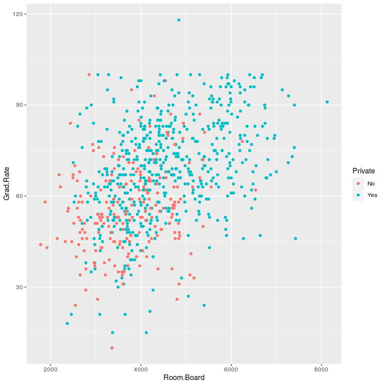

```r
ggplot(df,aes(Room.Board,Grad.Rate)) + geom_point(aes(color=Private))
```

Faz sentido ver que os colégios privados tem custos mais elevados.

Agora um histograma mostrando os estudantes de tempo integral colorido em privado ou não:

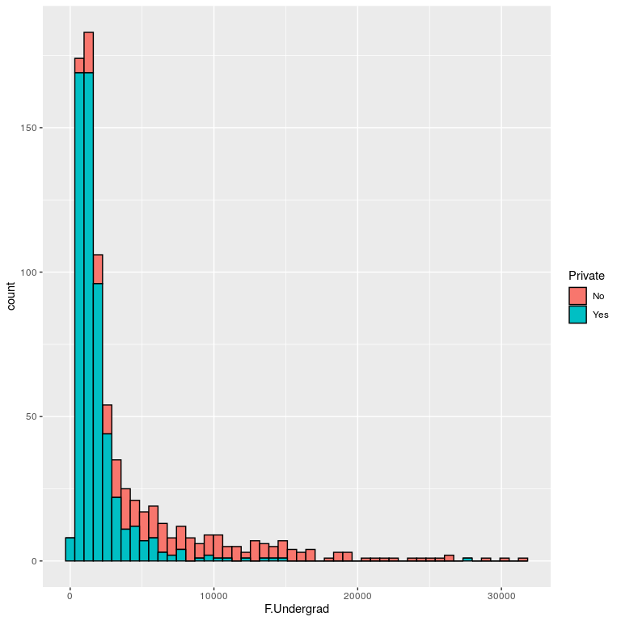

```r
ggplot(df,aes(F.Undergrad)) + geom_histogram(aes(fill=Private),color="black",bins=50)
```

Histograma da taxa de graduação, colorida se privada ou não:

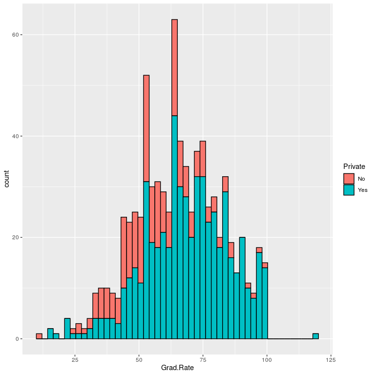

```r
ggplot(df,aes(Grad.Rate)) + geom_histogram(aes(fill=Private),color="black",bins=50)
```

Tem um colégio com a taxa de graduação acima de 100%. Vamos encontrá-lo e fixa-lo.

```r
subset(df,Grad.Rate>100)
```

|  | Private | Apps | Accept | Enroll | Top10perc | Top25perc | F.Undergrad | P.Undergrad | Outstate | Room.Board | Books | Personal | PhD | Terminal | S.F.Ratio | perc.alumni | Expend | Grad.Rate |
| --- | --- | --- | --- | --- | --- | --- | --- | --- | --- | --- | --- | --- | --- | --- | --- | --- | --- | --- |
| Cazenovia College | Yes | 3847 | 3433 | 527 | 9 | 35 | 1010 | 12 | 9384 | 4840 | 600 | 500 | 22 | 47 | 14.3 | 20 | 7697 | 118 |

Arrumando:

```r
df['Cazenovia College','Grad.Rate'] <- 100
```

Divisão de treino e teste:

```r
set.seed(101)

sample = sample.split(df$Private,SplitRatio=0.7)
train = subset(df,sample==T)
test = subset(df,sample==F)
```

Árvore de Decisão

Construindo o modelo e fazendo predições:

```r
tree <- rpart(Private ~ . ,method="class",data=train)
tree.preds <- predict(tree,test)
head(tree.preds)
```

```
                                                 No       Yes
Adrian College                          0.003311258 0.9966887
Alfred University                       0.003311258 0.9966887
Allegheny College                       0.003311258 0.9966887
Allentown Coll. of St. Francis de Sales 0.003311258 0.9966887
Alma College                            0.003311258 0.9966887
Amherst College                         0.003311258 0.9966887
```

Criando uma coluna nomeada “Private”, com as variáveis Sim/Não para indicar se o colégio é público ou não, para combinar com o dataframe original, assim podemos comparar os resultados facilmente:

```r
tree.preds <- as.data.frame(tree.preds)
tree.preds$Private <- ifelse(tree.preds$Yes > 0.5,"Sim","Não")
```

Checando a Matriz de confusão:

```r
table(tree.preds$Private,test$Private)
```

```
       No Yes
  Não  57   9
  Sim   7 160
```

Visualizando a árvore:

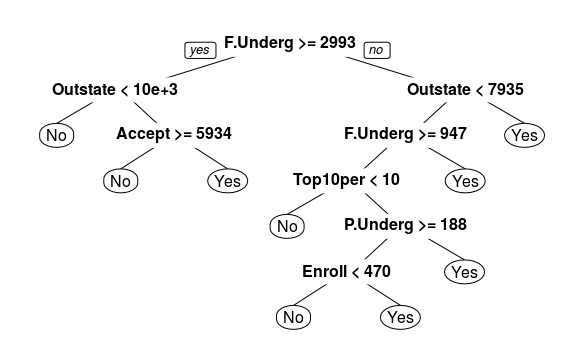

```r
library(rpart.plot)
prp(tree)
```

Floresta Aleatória

Carregando a livraria:

```r
library(randomForest)
```

Construindo o modelo:

```r
rf.model <- randomForest(Private ~ ., data=train,importance=TRUE)
```

Fazendo as predições:

```r
p <- predict(rf.model,test)
table(p,test$Private)
```

```
p      No Yes
  No   57   6
  Yes   7 163
```

Nós vemos que o modelo performou melhor que a árvore de decisão.

Projeto baseado no repositório de Sajal Sharma, elaborado em 11/12/2016. Link: https://rpubs.com/sajal_sharma/micro_dt_rf

Dados contidos na livraria ISLR, utilizados apenas para fins educacionais.

Traduzido e formatado por Alexsander Santos Psendziuk em 2020. Contato: alexpsendziuk@gmail.com